# Molecular Marker Assisted Plant Breeding

Introduction to geGWAS

Felipe Ferrão

University of Florida

**Objectives:**

- 60 minutes of hands-on
- Introduction to gwGWAS
- Running simulations in R using different approaches

**Extra information**

- [HOS 6236 – Website](https://lfelipe-ferrao.github.io/class/mas/)
- About the [author](https://lfelipe-ferrao.github.io/)
- About the [UF/IFAS Plant Breeding](https://programs.ifas.ufl.edu/plant-breeding/)

# Introduction

**Gene-by-environment (G×E) interactions are critical in genome-wide association studies (GWAS) because they help reveal how genetic effects vary across different environmental conditions.** While standard GWAS models identify loci associated with traits on average across environments, they often miss important genetic variants whose effects are condition-specific. By incorporating G×E analysis, researchers can detect loci that contribute to phenotypic plasticity—where the expression of a trait changes depending on the environment. This is especially important in agriculture, where breeding programs aim to develop genotypes that are not only high-performing but also stable across diverse climates, soils, or management practices. Identifying G×E interactions allows breeders and geneticists to pinpoint candidate genes that may confer resilience or sensitivity to particular environments, ultimately supporting more targeted breeding strategies and better understanding of complex trait architecture.

# Methods for geGWAS analysis

There are several statistical methods and software tools available to analyze geGWAS, with several good reviews in the literature. Here, I will categorize it into three main approaches.

1. **Multivariate models** treat trait expression in different environments as correlated traits, allowing for the joint estimation of genetic effects and their covariance across environments—examples include multi-trait mixed models and multi-environment BLUP frameworks.
2. **Plasticity-based approaches**, such as **Finlay–Wilkinson (FW) regression** or **reaction norm**, model the genotype-specific response across environmental indices (e.g., environmental means), capturing both the average performance (intercept) and sensitivity (slope) of each genotype. Finally
3. **ANOVA-based methods**, often implemented using linear mixed models, include environment and genotype-by-environment terms to test for interaction effects explicitly, often using likelihood ratio tests or variance partitioning.

Each of these methods offers different insights into G×E dynamics, from stable QTL detection to environment-specific genetic effects, and the choice of method depends on the study goals, data structure, and computational resources.

## Multivariate mixed model GWAS

### Multi-trait mixed models

The use of multivariate (or multi-trait) mixed models it an extension of the univariate version where the environment information are considered different traits in the model formulation. Below, e can write the multivariate GWAS model in matrix form as follows:

$$\mathbf{Y} = \mathbf{X}\mathbf{B} +
\mathbf{Z}\mathbf{U} + \mathbf{E}$$

Where the random genetic effects follow: $\text{vec}(\mathbf{U}) \sim \mathcal{N}\left(0, \mathbf{K} \otimes \mathbf{G}\right)$ and the residuals follow: $\text{vec}(\mathbf{E}) \sim \mathcal{N}\left(0, \mathbf{I}_n \otimes \mathbf{R}\right)$. With the variance and covariance as:

$$\mathbf{G} =
\begin{bmatrix}
\sigma^2_{g1} & \sigma_{g12} & \sigma_{g13} \\
\sigma_{g12} & \sigma^2_{g2} & \sigma_{g23} \\
\sigma_{g13} & \sigma_{g23} & \sigma^2_{g3} \\
\end{bmatrix}$$

$$\mathbf{R} =
\begin{bmatrix}
\sigma^2_{e1} & \sigma_{e12} & \sigma_{e13} \\
\sigma_{e12} & \sigma^2_{e2} & \sigma_{e23} \\
\sigma_{e13} & \sigma_{e23} & \sigma^2_{e3}
\end{bmatrix}$$

Below, we present an example in the matrix notaito where we have 3 individuals (n) and 3 environments (t). The full model can be represented as:

$$\underbrace{
\begin{bmatrix}
y_{11} & y_{12} & y_{13} \\
y_{21} & y_{22} & y_{23} \\
y_{31} & y_{32} & y_{33}
\end{bmatrix}
}_{\mathbf{Y}\ (3 \times 3)}
=
\underbrace{
\begin{bmatrix}
1 & 0 & 0 \\
1 & 0 & 0 \\
1 & 0 & 0 \\
0 & 1 & 0 \\
0 & 1 & 0 \\
0 & 1 & 0 \\
0 & 0 & 1 \\
0 & 0 & 1 \\
0 & 0 & 1
\end{bmatrix}
}_{\mathbf{X}\ (9 \times 3)}
\cdot
\underbrace{
\begin{bmatrix}
\beta_1 \\
\beta_2 \\
\beta_3
\end{bmatrix}
}_{\mathbf{B}\ (3 \times 1)}
+
\underbrace{
\begin{bmatrix}
1 & 0 & 0 \\
0 & 1 & 0 \\
0 & 0 & 1 \\
1 & 0 & 0 \\
0 & 1 & 0 \\
0 & 0 & 1 \\
1 & 0 & 0 \\
0 & 1 & 0 \\
0 & 0 & 1
\end{bmatrix}
}_{\mathbf{Z}\ (9 \times 3)}
\cdot
\underbrace{
\begin{bmatrix}
u_{11} & u_{12} & u_{13} \\
u_{21} & u_{22} & u_{23} \\
u_{31} & u_{32} & u_{33}
\end{bmatrix}
}_{\mathbf{U}\ (3 \times 3)}
+
\underbrace{
\begin{bmatrix}
e_{11} & e_{12} & e_{13} \\
e_{21} & e_{22} & e_{23} \\
e_{31} & e_{32} & e_{33}
\end{bmatrix}
}_{\mathbf{E}\ (3 \times 3)}$$

### GEMMA models

Among the software that performe multi-trait analyses, **GEMMA** (Genome-wide Efficient Mixed Model Association) can accommodate univariate and multivariate analyses, which means analyzing multiple related phenotypes simultaneously. The multivariate linear mixed model used in GEMMA can be written as:

$$\mathbf{y} = \mathbf{W}\boldsymbol{\alpha} + \mathbf{x}_j \beta_j +
\mathbf{u} + \boldsymbol{\varepsilon}$$

Where:

- $\mathbf{y}$: vector of phenotypes (length $n$)
- $\mathbf{W}$: matrix of covariates (e.g., intercept, principal components)
- $\boldsymbol{\alpha}$: fixed effects associated with covariates
- $\mathbf{x}_j$: vector of genotypes at SNP $j$
- $\beta_j$: **effect size of SNP $j$** (the target of estimation)
- $\mathbf{u} \sim \mathcal{N}(0, \lambda \tau^{-1} \mathbf{K})$: random genetic background effects, modeled via a kinship matrix $\mathbf{K}$
- $\boldsymbol{\varepsilon} \sim \mathcal{N}(0, \tau^{-1} \mathbf{I})$: residual error
- $\lambda$: ratio of polygenic to residual variance
- $\tau^{-1}$: residual variance

GEMMA estimates several key outputs for each SNP, including:

- **Effect size ($\beta_j$)**: Indicates the strength and direction of the SNP’s association in each environment
- **P-value**: Statistical significance of the SNP-phenotype association.
- **Covariance between traits**: Represents the correlation of genetic effects across multiple phenotypes.
- The magnitude of $\beta_j$ reflects how strongly the SNP influences each trait.
- The sign of $\beta_j$ indicates whether the SNP increases or decreases the trait value.
- Low p-values suggest significant SNP-phenotype associations with one or more of the phenotypes
- Variance-Covariance Matrix of Traits ($\Sigma$) reflects how traits co-vary genetically and therefore indicate whether the same variants affect multiple traits similarly or oppositely.

Despite the elegance and power of including multiple traits simultaneously in the model– which allows borrowing information across correlated responses – this method has a major drawback: it often faces **convergence issues** when the number of traits exceeds five (in general). Additionally, breeders often seek a better understanding of concepts related to plasticity and stability, which motivates the use of alternative or complementary methods.

## Plasticity-based GWAS

Combining plasticity analysis with GWAS provides a powerful framework to uncover the genetic basis of how genotypes respond to varying environments. By integrating phenotypic plasticity—typically quantified through regression slopes or reaction norms—with genome-wide association studies, researchers can identify genetic variants that not only affect trait means but also influence the stability or responsiveness of traits across environments.

### Finlay and Wilkinson GWAS

An attractive alternative to study the GxE interaction in the plant breeding literature uses regression on the mean model. [Finlay and Wilkinson (1963)](http://www.publish.csiro.au/cp/AR9630742) regression describes GxE interaction as a regression line on the environmental quality.

The Finlay–Wilkinson regression requires regressing the observed phenotypes of the line on environment effects. In the absence of explicit environmental information, the biological quality of an environment can be reflected in the average performance of all genotypes in that environment. Good environments will have a high average genotypic performance, and bad environments will have a low average genotypic performance. Thus, the GxE part is then described by a regression slopes on the environmental quality, as:

$$y_{ijk} = \mu + g_i + \hat{h}_j +
b_i\hat{h}_j + \epsilon_{ijk}$$

In short, regression on the mean model describes GxE in terms of parameters that can be given some biological meaning, including to central concepts of **adaptability** and **stability** – or in another words, **broad** and **specific** adaptation.

- Stability: genotypes with high mean (intercept) and $b_i=1$; it represents a group of genotypes that respond satisfactorily in all environmental conditions. Ex: some potato breeding programs in US that is looking for genotypes with broad adaptation.
- Low adaptability: high means and $b_i> 1$; it represents a group of genotypes that present differential responses for favorable environments. In the case of plants, such materials are considered with high risk for cultivation in places with low technology and therefore with unfavorable environmental conditions.
- High adaptability: high means and $b_i< 1$; it represents a group of genotypes that present differential responses for unfavorable environments. The fact that such genotypes maintain high performance even in unfavorable environments makes them as rustic or robust materials. In general, such genotypes are not recommended for high-tech regions.

In the sequence, a simple representation on how the FW regression works:

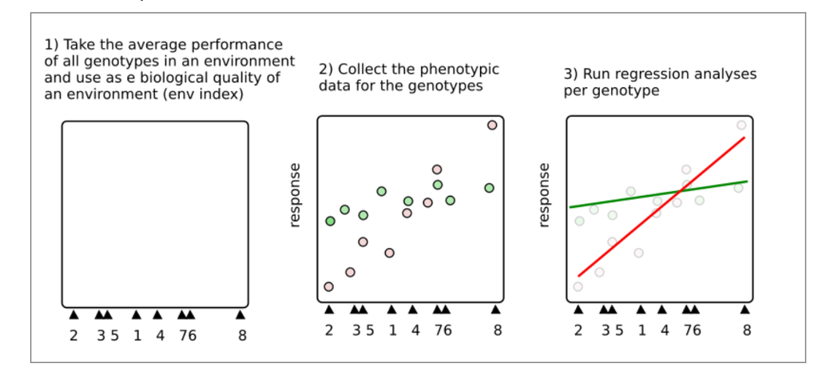

FW regression in a toy example considering 8 enviroments and two genotypes with a stable (green) and specific (red) adaptability

There are several recent papers using this strategy:

- [Hudson et al., 2022](https://academic.oup.com/g3journal/article/12/3/jkac013/6520465?login=true).
- [Wei et al., 2024](https://onlinelibrary.wiley.com/doi/full/10.1111/pce.15213)
- [Ozair et al., 2025](https://acsess.onlinelibrary.wiley.com/doi/full/10.1002/tpg2.70078)

A model for that was described by [Hudson et al., 2022](https://academic.oup.com/g3journal/article/12/3/jkac013/6520465?login=true) as :

$$s = X_m \beta_s + Z_{G1}u_s +
e$$

where we are testing if the marker significantly predicted the slope of each genotype. To this end, the s a vector with the slopes coming from the FW regressions, $\beta_s$ is a vector of marker effects, and $u_s$ is the genotypic effect (polygenic term) with covariance proportional to the kinship matrix (**K**).

## ANOVA based models

### Introduction: Testing G×E Effects Using Complete vs. Reduced Models

One robust and widely used approach to evaluate the presence and importance of G×E effects in GWAS or mixed model frameworks is the comparison of **complete** and **reduced** models using the **likelihood ratio test (LRT)**.

The **reduced model** assumes that the effect of a genetic variant is consistent across all environments (i.e., no G×E interaction):

$$\text{Reduced Model:} \quad y_{ij} = \mu + \beta_1 + G_i + E_j +
\varepsilon_{ij}$$

In contrast, the **complete model** allows the effect of the genotype and the SNP effect to vary across environments, explicitly modeling the G×E interaction:

$$\text{Complete Model:} \quad y_{ij} = \mu + \beta_1 + G_i +E_j + (G
\times E)_{ij} + \varepsilon_{ij}$$

Where:

- $y_{ij}$ is the phenotype of genotype ( i ) in environment ( j )
- $\beta_1$ is the marker effect
- $\mu$ is the overall mean,
- $G_i$ is the main effect of genotype ( i ), with covariance proportional to the kinship matrix (**K**)
- $E_j$ is the effect of environment ( j ),
- ($G \times E)_{ij}$ represents the interaction between genotype ( i ) and environment ( j ),
- $\varepsilon_{ij}$ is the residual error.

To formally test whether the inclusion of G×E improves model fit, we apply the **likelihood ratio test (LRT)**:

$$\text{LRT} = -2 \left( \log L_{\text{reduced}} - \log
L_{\text{complete}} \right)$$

This LRT statistic follows a chi-squared distribution under the null hypothesis (no G×E effect), with degrees of freedom equal to the difference in the number of parameters between the models. A significant LRT indicates that modeling G×E provides a significantly better fit to the data, suggesting the presence of genotype-by-environment interaction for the tested variant. This modeling framework enables researchers and breeders to not only identify markers associated with average performance but also those involved in plasticity and environmental responsiveness—essential components in breeding for stability and adaptability.

Example in the literature:

- [Sakai et al., 2023](https://academic.oup.com/g3journal/article/13/6/jkad082/7117618#440550919)

# Hands-on

## Simulated example

This simulation demonstrates a toy example of genotype-by-environment interaction. It includes simulation of genotype and phenotype data across 5 environments with shared and environment-specific QTL effects. We then perform GWAS separately in each environment to detect significant marker-trait associations.

### Simulation Parameters

We simulate genotype data for:

- `n_ind = 200` individuals
- `n_chr = 3` chromosomes
- `100` markers per chromosome → `300` markers total

In this example we will consider a situation where two contrasting environments were tested. It could be irrigated and non-irrigated, for example. To this end, we will assume QTL of large effect on a give phenotypic trait (yield, for example) in a scenario where a stable QTL is expressed across all the enviroments, and some QTL are specific to the environmental conditions. We simulate 5 QTL as:

- `qtl1`: Stable (shared across all environments)
- `qtl2` & `qtl4`: Specific to non-favorable environments
- `qtl3` & `qtl5`: Specific to favorable environments

Assuming different QTL profile per environment, we will simulate phenotypic values using an additive model of QTL effects plus normally distributed noise, the noise here could be considered a random variation within the environments.

$$y_i = \sum_{j \in \text{QTL}} g_{ij}
\beta_j + \varepsilon_i, \quad \varepsilon_i \sim \mathcal{N}(0,
\sigma^2)$$

Where:$g_{ij}$ is the genotype at QTL ( j ) for individual ( i ); $\beta_j$ is the effect size of QTL ( j ) and $\varepsilon_i$ is random enviromental noise

For the GWAS analysis, we will use a simple regression marker analyses and ignore the population structure. This is a toy example and we simulated the original data without any evident populations tructure that could create sporius association. The following simple linear regression per marker was used:

$$y_i = \mu + \beta_jx_{ij} +
\varepsilon_i$$

Where:$x_{ij}$ is the genotype of individual ( i ) at SNP ( j ); and $\beta_j$ is the SNP effect being tested.

Results will be ploted using the `qqman` R package to plot.

**Simulation codes**

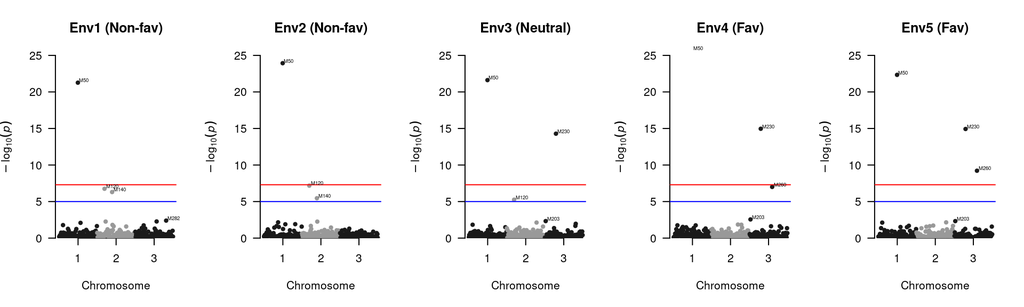

```r
# Simulation parameters
set.seed(123)
n_ind <- 200
n_chr <- 3
markers_per_chr <- 100
total_markers <- n_chr * markers_per_chr

# Simulate Genotype Matrix
geno_matrix <- matrix(sample(0:2, n_ind * total_markers, replace = TRUE),
                      nrow = n_ind, ncol = total_markers)

chr <- rep(1:n_chr, each = markers_per_chr)
marker_pos <- 1:total_markers
marker_names <- paste0("M", marker_pos)
colnames(geno_matrix) <- marker_names

# Define QTLs and Effects
qtl1 <- 50    # Stable QTL on Chr1
qtl2 <- 120   # Non-favorable-specific (Chr2)
qtl3 <- 230   # Favorable-specific (Chr3)
qtl4 <- 140   # Non-favorable-specific (Chr2)
qtl5 <- 260   # Favorable-specific (Chr3)

effects <- list(qtl1 = 1.5,qtl2 = 1.0,qtl3 = 1.2,
                qtl4 = 0.8, qtl5 = 1.1)

# Simulated phenotypes
simulate_pheno <- function(qtl_ids, effects, noise_sd = 1) {
  pheno <- rep(0, n_ind)
  for (qtl in qtl_ids) {
    idx <- which(c(qtl1, qtl2, qtl3, qtl4, qtl5) == qtl)
    pheno <- pheno + geno_matrix[, qtl] * effects[[paste0("qtl", idx)]]
  }
  pheno <- pheno + rnorm(n_ind, 0, noise_sd)
  return(pheno)
}

# Define five environments with different QTL combinations:
phen_env1 <- simulate_pheno(c(qtl1, qtl2, qtl4), effects)  # Non-favorable
phen_env2 <- simulate_pheno(c(qtl1, qtl2, qtl4), effects)  # Non-favorable
phen_env3 <- simulate_pheno(c(qtl1, qtl2, qtl3), effects)  # Neutral
phen_env4 <- simulate_pheno(c(qtl1, qtl3, qtl5), effects)  # Favorable
phen_env5 <- simulate_pheno(c(qtl1, qtl3, qtl5), effects)  # Favorable

# Run GWAS for Each Environment
run_gwas <- function(pheno) {
  sapply(1:total_markers, function(i) {
    model <- lm(pheno ~ geno_matrix[, i])
    summary(model)$coefficients[2, 4]
  })
}

pvals_env1 <- run_gwas(phen_env1)
pvals_env2 <- run_gwas(phen_env2)
pvals_env3 <- run_gwas(phen_env3)
pvals_env4 <- run_gwas(phen_env4)
pvals_env5 <- run_gwas(phen_env5)

# Plot the results
library(qqman)
# ---- Combine into results dataframe ----
results <- data.frame(
  Marker      = marker_names,
  Chromosome  = chr,
  Position    = marker_pos,
  P_Env1      = pvals_env1,
  P_Env2      = pvals_env2,
  P_Env3      = pvals_env3,
  P_Env4      = pvals_env4,
  P_Env5      = pvals_env5
)

# ---- Manhattan plots ----
par(mfrow = c(1, 5))
manhattan(data.frame(SNP=marker_names, CHR=chr, BP=marker_pos, P=pvals_env1),
          ylim=c(0,25),annotatePval = 0.005,annotateTop = F,main = "Env1 (Non-fav)")
manhattan(data.frame(SNP=marker_names, CHR=chr, BP=marker_pos, P=pvals_env2),
           annotatePval = 0.005,annotateTop = F,ylim=c(0,25),     main = "Env2 (Non-fav)")
manhattan(data.frame(SNP=marker_names, CHR=chr, BP=marker_pos, P=pvals_env3),
           annotatePval = 0.005,  annotateTop = F,ylim=c(0,25),
          main = "Env3 (Neutral)")
manhattan(data.frame(SNP=marker_names, CHR=chr, BP=marker_pos, P=pvals_env4),
           annotatePval = 0.005,annotateTop = F,  ylim=c(0,25),
          main = "Env4 (Fav)")
manhattan(data.frame(SNP=marker_names, CHR=chr, BP=marker_pos, P=pvals_env5),
           annotatePval = 0.005,annotateTop = F,  ylim=c(0,25),   main = "Env5 (Fav)")
```

## FW GWAS model

**Finlay–Wilkinson model** per genotype:

$$y_{ij} = \beta_{0i} + \beta_{1i} \cdot
\bar{E}*j + \varepsilon*{ij}$$

**GWAS model** for slope:

$$\text{Trait}_i = \mu + \gamma_j \cdot
\text{SNP}*{ij} + \varepsilon_i$$

This approach integrates **phenotypic plasticity analysis** with **genomic association**, helping identify loci that control not only performance but also stability across environments.

**R codes**

```r
library(dplyr)
library(ggplot2)
# ---- Format phenotype data (long format) ----
phenotypes_long <- data.frame(
  id = rep(1:n_ind, times = 5),
  genotype = rep(paste0("G", 1:n_ind), times = 5),
  environment = factor(rep(paste0("Env", 1:5), each = n_ind),
                       levels = paste0("Env", 1:5)),
  trait = c(phen_env1, phen_env2, phen_env3, phen_env4, phen_env5)
)

# ---- Calculate environmental means (environmental index) ----
env_means <- phenotypes_long %>%
  group_by(environment) %>%
  summarise(env_mean = mean(trait), .groups = "drop")

# ---- Merge to main data ----
pheno_fw <- phenotypes_long %>%
  left_join(env_means, by = "environment")

# ---- Finlay-Wilkinson regression per genotype ----
fw_results <- pheno_fw %>%
  group_by(genotype) %>%
  do({
    model <- lm(trait ~ env_mean, data = .)
    data.frame(
      intercept = coef(model)[1],
      slope = coef(model)[2],
      r2 = summary(model)$r.squared
    )
  }) %>%
  ungroup()

# ---- View plasticity results ----
head(fw_results)
```

```
## # A tibble: 6 × 4
##   genotype intercept  slope     r2
##   <chr>        <dbl>  <dbl>  <dbl>
## 1 G1         -11.4    4.56  0.667
## 2 G10         -6.88   2.47  0.298
## 3 G100         9.30  -1.25  0.450
## 4 G101       -17.4    6.24  0.271
## 5 G102        -6.29   2.28  0.515
## 6 G103         0.521  0.826 0.0698
```

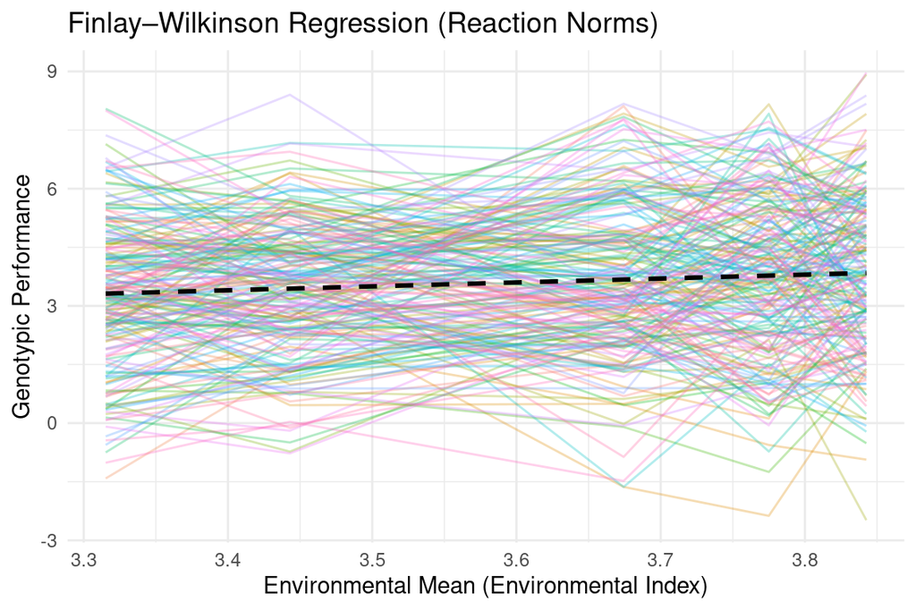

```r
# ---- Plot reaction norms (Finlay-Wilkinson lines) ----
ggplot(pheno_fw, aes(x = env_mean, y = trait, group = genotype)) +
  geom_line(aes(color = genotype), alpha = 0.3) +
  geom_smooth(aes(group = 1), method = "lm", color = "black", se = FALSE, linetype = "dashed") +
  labs(
    title = "Finlay–Wilkinson Regression (Reaction Norms)",
    x = "Environmental Mean (Environmental Index)",
    y = "Genotypic Performance"
  ) +
  theme_minimal() +
  theme(legend.position = "none")
```

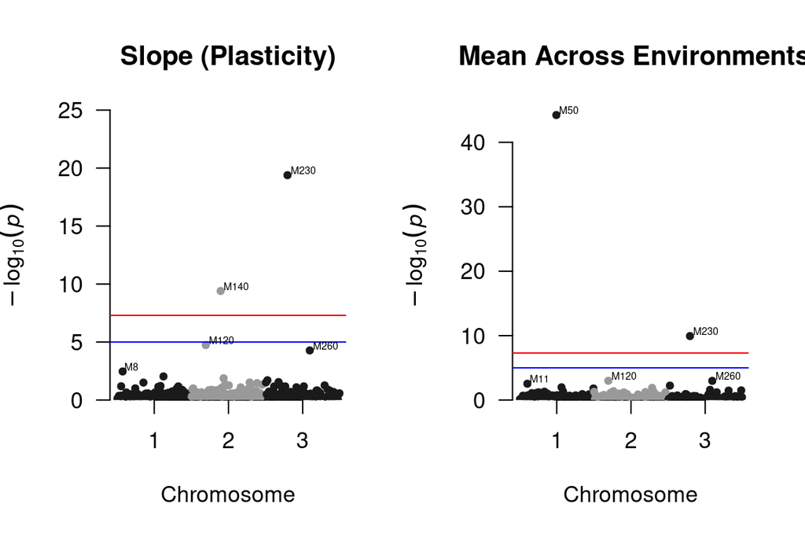

```r
# ---- Prepare FW phenotype data for GWAS ----
# Make sure genotype labels match (geno_matrix rownames)
rownames(geno_matrix) <- paste0("G", 1:n_ind)  # same as in fw_results

# Create phenotype dataframes
pheno_intercept <- fw_results %>%
  select(genotype, intercept) %>%
  rename(id = genotype, pheno = intercept)

pheno_slope <- fw_results %>%
  select(genotype, slope) %>%
  rename(id = genotype, pheno = slope)


# ---- GWAS Function ----
run_gwas <- function(pheno_df) {
  pvals <- sapply(1:ncol(geno_matrix), function(i) {
    model <- lm(pheno_df$pheno ~ geno_matrix[pheno_df$id, i])
    summary(model)$coefficients[2, 4]
  })
  return(pvals)
}

# ---- Run GWAS ----
pval_slope <- run_gwas(pheno_slope)

# ---- Prepare for Manhattan plot ----
gwas_df_slope <- data.frame(
  SNP = colnames(geno_matrix),
  CHR = chr,
  BP  = marker_pos,
  P   = pval_slope
)


# ---- Plot Manhattan plots ----
par(mfrow = c(1, 2))
manhattan(gwas_df_slope,
         annotatePval = 0.005,annotateTop = F,  ylim=c(0,25),
         main = "Slope (Plasticity)")

# ---- Compute mean phenotype across all environments ----
pheno_matrix <- cbind(phen_env1, phen_env2, phen_env3, phen_env4, phen_env5)
pheno_mean <- rowMeans(pheno_matrix)

# ---- GWAS on the average phenotype ----
pvals_mean <- sapply(1:ncol(geno_matrix), function(i) {
  model <- lm(pheno_mean ~ geno_matrix[, i])
  summary(model)$coefficients[2, 4]
})

# ---- Create Manhattan plot data ----
gwas_df_mean <- data.frame(
  SNP = colnames(geno_matrix),
  CHR = chr,
  BP  = marker_pos,
  P   = pvals_mean
)

# ---- Plot Manhattan plot ----
manhattan(gwas_df_mean,
          annotatePval = 0.005,annotateTop = F,
          main = " Mean Across Environments")
```

**Some conclusions**

- The use of the slope as a metric for GxE could capture the markers associated with specific effects per environment, indicating that such approach can be used to map hits with adaptability to a given environmental condition.
- The common marker effect in the `chr1` was mapped using a regular GWAS model and considering the phenotype as the average across all the environments as the phenotypic metric.
- The FW results in the biplot analyses show genotypes with different plasticity patterns and cross-over interactions – both facts that supportthe presence of GxE interacttion.

## ANOVA based models

To formally assess the importance of genotype-by-environment (G×E) interactions, we use the `lme4qtl` R package—an extension of the widely used `lme4` package. The key advantage of `lme4qtl` lies in its ability to incorporate a **kinship matrix** to model the polygenic background, making it particularly suitable for genetic analyses. While the underlying structure of the model remains similar to traditional mixed models, the inclusion of the polygenic term renders it more comprehensive and biologically realistic. This allows for a more accurate partitioning of genetic variance and a robust test of G×E effects within a linear mixed model framework.

The code of the code is presented in the sequence:

- Reduded model: `model1 <- relmatLmer(pheno ~ SNP + (1|id) + (1|Env), df, relmat = list(id = K))`
- Full model: `model2 <- relmatLmer(pheno ~ SNP + (1|id) + (1+SNP|Env), df, relmat = list(id = K)`
- LRT: `pval <- anova(model1, model2)[2, "Pr(>Chisq)"]`

**R codes**

```r
# ---- Load libraries ----
library(lme4qtl)
library(rrBLUP)
library(dplyr)
library(tidyr)

# ---- Your simulated data ----
# Assuming you already have:
# - geno_matrix (individuals × markers)
# - phen_env1 ... phen_env5 (phenotype vectors)
# - marker_names, chr, marker_pos

# ---- Format data ----
# Create long-form phenotype data
pheno_long <- data.frame(
  id = rep(1:nrow(geno_matrix), times = 5),
  Env = factor(rep(paste0("Env", 1:5), each = nrow(geno_matrix))),
  pheno = c(phen_env1, phen_env2, phen_env3, phen_env4, phen_env5)
)

# ---- Create genotype matrix in required format ----
geno_df <- data.frame(
  SNP = marker_names,
  CHR = chr,
  POS = marker_pos,
  t(geno_matrix)
)
colnames(geno_df)[-c(1:3)] <- as.character(1:nrow(geno_matrix))

# ---- Create additive relationship matrix ----
M <- geno_matrix - 1  # Convert to 0,1,2 coding
K <- A.mat(M)

# ---- Function to compute GxE interaction per SNP ----
score.calc <- function(geno_df, pheno_long, K) {
  m <- nrow(geno_df)
  scores <- numeric(m)

  for (i in 1:m) {
    print(m)
    snp_vector <- as.numeric(geno_df[i, -(1:3)])
    snp_df <- data.frame(
      id = 1:length(snp_vector),
      SNP = snp_vector
    )

    df <- merge(pheno_long, snp_df, by = "id")
    df$id= paste0("G",df$id)

    model1 <- relmatLmer(pheno ~ SNP + (1|id) + (1|Env), df, relmat = list(id = K), REML = FALSE)
    model2 <- relmatLmer(pheno ~ SNP + (1|id) + (1+SNP|Env), df, relmat = list(id = K), REML = FALSE)

    # LRT for interaction
    pval <- anova(model1, model2)[2, "Pr(>Chisq)"]
    scores[i] <- pval
    cat("SNP", i, "/", m, "P:", signif(pval, 3), "\n")
  }

  return(scores)
}

# ---- Run the GxE test ----
scores <- score.calc(geno_df, pheno_long, K)

# ---- Combine and view results ----
result <- geno_df[, 1:3]
result$Pval_GxE <- scores

# View top markers
head(result[order(result$Pval_GxE), ], 10)

gwas_df_gxe <- data.frame(
  SNP = colnames(geno_matrix),
  CHR = chr,
  BP  = marker_pos,
  P   = scores
)

save(gwas_df_gxe, file="/home/felipe/Dropbox (UFL)/classes/Molecular_Breeding/class5_GWAS/GXE/lme4QTL.Rdata")
```

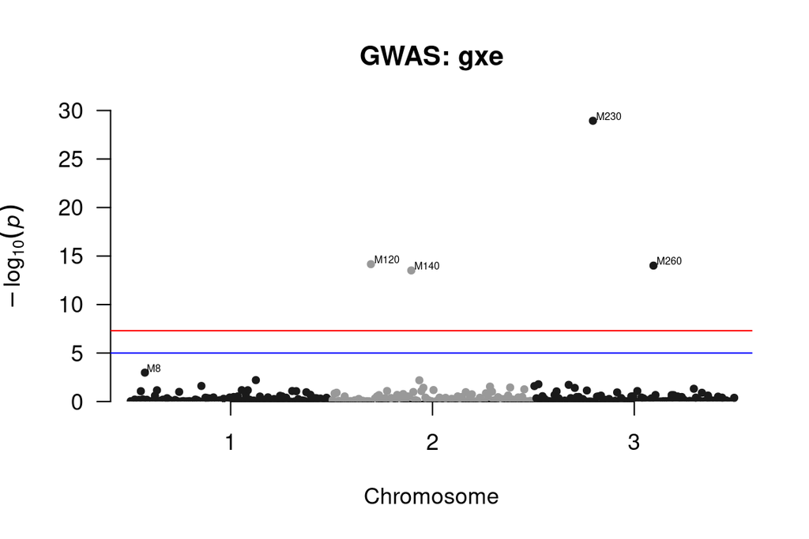

```r
load("/home/felipe/Dropbox (UFL)/classes/Molecular_Breeding/class5_GWAS/GXE/lme4QTL.Rdata")
manhattan(gwas_df_gxe,
           annotatePval = 0.005,annotateTop = F,ylim=c(0,30),
          main = "GWAS: gxe")
```

**Some comments**

- In theory, it is not a fully fair comparison, because the GWAS model implemented via `lme4qtl` includes a polygenic term that accounts for relatedness among individuals.
- In my experience, the use of **full versus reduced models** (e.g., testing for G×E by comparing models with and without interaction terms) tends to produce **cleaner Manhattan plots**, with **stronger and more distinct association signals** (i.e., higher –log10(p-values)).
- This clarity makes it easier to interpret the results and identify candidate loci with potential interaction effects.
- This advantage comes at the cost of **increased computational time**

# Conclusions

In conclusion, multiple statistical approaches are available to study G×E interactions in the context of genome-wide association studies (GWAS), each offering distinct advantages depending on the experimental design and research objective. The different methods used to assess G×E interactions in GWAS vary significantly in their computational demands.

- **Finlay–Wilkinson (FW) regression** is generally the most computationally efficient, as it simplifies the problem into two separate steps—first estimating plasticity parameters (slope and intercept) for each genotype, then performing GWAS on these parameters. This decoupling allows for fast computation, even with large datasets.
- **Multivariate GWAS** offers a more elegant framework by jointly modeling all traits or environments and estimating their effects simultaneously. However, this approach quickly becomes computationally intensive and often faces convergence issues when the number of environments exceeds five or six.
- **ANOVA-based mixed models** are grounded in well-established models of G×E interaction and provide robust statistical inference. Yet, they also come with higher computational costs due to the complexity of fitting multiple random effects and testing interaction terms using likelihood ratio tests. Therefore, the choice of method should consider both the biological goals and available computational resources.

# References

- Napier et al., 2022. Gene-by-environment interactions in plants: Molecular mechanisms, environmental drivers, and adaptive plasticity. The Plant Cell. [Link](https://academic.oup.com/plcell/article/35/1/109/6808642)
- Sakai et al., 2023. Whole-genome analysis of recombinant inbred rice lines reveals a quantitative trait locus on chromosome 3 with genotype-by-environment interaction effects. G3 journal. [Link](https://academic.oup.com/g3journal/article/13/6/jkad082/7117618#440550919)
- Herrera-Luis et al., 2024. Gene–environment interactions in human health. Nature Genetics. [Link](https://www.nature.com/articles/s41576-024-00731-z)
- Hudson et alk., 2022. Analysis of genotype-by-environment interactions in a maize mapping population. G3 journal. [Link](https://academic.oup.com/g3journal/article/12/3/jkac013/6520465?login=true)
- Ozair et al., 2025. Phenotypic plasticity in maize grain yield: Genetic and environmental insights of response to environmental gradients. The Plant Genome [Link](https://acsess.onlinelibrary.wiley.com/doi/full/10.1002/tpg2.70078)
- Wei et al., (2024) Genetic and Environmental Patterns Underlying Phenotypic Plasticity in Flowering Time and Plant Height in Sorghum. Plant Cell and Environment. [Link](https://onlinelibrary.wiley.com/doi/full/10.1111/pce.15213)